# 260-2019-04-02-action-II

2019-04-01 16:49:02

## Today's Topics

- Exam 3 next Thursday, April 11
- Warm-up
- Wrap-up on the neuroscience of action

## Warm-up

## Which of the following sensory questions is the purview of *exteroceptive* systems?

- Do I have a fever?
- Is it warm enough outside to play frisbee?
- Am I hungry?
- Am I tired?

## Which of the following sensory questions is the purview of *exteroceptive* systems?

- Do I have a fever?
- **Is it warm enough outside to play frisbee?**
- Am I hungry?
- Am I tired?

## Which of the following would *not* be useful in measuring a neuron's receptive field?

- Recording from the neuron
- Stimulating the skin/retina/cochlea with different patterns & intensities
- Characterizing the stimulation patterns that change responses
- Using fMRI to record from sensory cortex

## Which of the following would *not* be useful in measuring a neuron's receptive field?

- Recording from the neuron
- Stimulating the skin/retina/cochlea with different patterns & intensities
- Characterizing the stimulation patterns that change responses
- **Using fMRI to record from sensory cortex**

## The flow of calcium (\(Ca^{++}\)) ions into the cell affects which of the following:

1. The exocytosis of neurotransmitter
2. The contraction of muscle fiber
3. Neurotransmitter reuptake
4. both 1. and 2.

## The flow of calcium (\(Ca^{++}\)) ions into the cell affects which of the following:

1. The exocytosis of neurotransmitter
2. The contraction of muscle fiber
3. Neurotransmitter reuptake
4. **both 1. and 2.**

## Neuroscience of action

## Muscle contraction

[video not shown]

## Muscles are sensory organs, too!

[figure not shown]

## Two muscle fiber types

[figure not shown]

## Two muscle fiber types

- Intrafusal fibers
  - Sense length/tension
  - Contain muscle spindles linked to Ia afferents
  - ennervated by gamma (\(\gamma\)) motor neurons
- Extrafusal fibers
  - Generate force
  - ennervated by alpha (\(\alpha\)) motor neurons

## Monosynaptic stretch (myotatic) reflex

- Muscle stretched (length increases)
- Muscle spindle in intrafusal fiber activates
- Ia afferent sends signal to spinal cord
  - Activates alpha (\(\alpha\)) motor neuron
- Muscle contracts, shortens length

## Monosynaptic stetch (myotatic) reflex

[figure not shown]

- Gamma (\(\gamma\)) motor neuron fires to take up intrafusal fiber slack

[figure not shown]

## Monosynaptic stretch (myotatic) reflex

[figure not shown]

## Why doesn't antagonist muscle respond?

[figure not shown]

## Why doesn't antagonist muscle respond?

- Polysynaptic inhibition of antagonist muscle
- Prevents/dampens tremor

## Brain gets fast(est) sensory info from spindles

[figure not shown]

## How the brain controls the muscles

- Pyramidal tracts
  - Pyramidal cells (Cerebral Cortex Layer 5) in primary motor cortex (M1)
  - Corticobulbar (cortex -> brainstem) tract
  - Corticospinal (cortex -> spinal cord) tract
- Crossover (decussate) in medulla
  - L side of brain ennervates R side of body

## Corticospinal tract

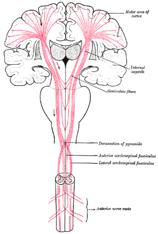

https://commons.wikimedia.org/wiki/File:Gray764.png#/media/File:Gray764.png

## How the brain controls the muscles

- Extrapyramidal system
  - Tectospinal tract
  - Vestibulospinal tract
  - Reticulospinal tract
- Involuntary movements
  - Posture, balance, arousal

## Extrapyramidal system

[figure not shown]

https://upload.wikimedia.org/wikipedia/commons/b/be/Gray672.png

This figure shows that the descending motor pathways in red on the right have their own spatial organization depending on where they originate in the brain.

## Disorders

- Parkinson's
- Huntington's

## The Faces of Parkinson's

[video not shown]

## Parkinson's

- Slow, absent movement, resting tremor
- Cognitive deficits, depression
- DA Neurons in substantia nigra degenerate
- Treatments
  - DA agonists
  - DA agonists linked to impulse control disorders in ~1/7 patients [(Ramirez-Zamora et al. 2016)](http://dx.doi.org/10.1586/14737175.2016.1158103)
  - Levodopa (L-Dopa), DA precursor

## Huntington's

[figure not shown]

http://cp91279.biography.com/1000509261001/1000509261001_1733824754001_woody-guthrie-centennial-1.jpg

## Huntington's

- Formerly Huntington’s Chorea
  - "Chorea" from Greek for "dance"
  - “Dance-like” pattern of involuntary movements
- Cognitive decline
- Genetic + environmental influences
- Disturbance in striatum
- No effective treatment

## Huntington's

[video not shown]

## Final thoughts

- Control of movement determined by multiple sources
- Cerebral cortex + basal ganglia + cerebellum + spinal circuits

## Next time…

- Vision

## References

Ramirez-Zamora, Adolfo, Lucy Gee, James Boyd, and José Biller. 2016. “Treatment of Impulse Control Disorders in Parkinson’s Disease: Practical Considerations and Future Directions.” *Expert Review of Neurotherapeutics* 16 (4): 389–99. doi:10.1586/14737175.2016.1158103.